# (Fasaha Capstone Project)

Data Dictionary:

● ID: Unique ID of each customer ● Year_Birth: Age of the customer ● Education: Customer's level of education ● Marital_Status: Customer's marital status ● Kidhome: Number of small children in customer's household ● Teen home: Number of teenagers in customer's household ● Income: Customer's yearly household income ● Recency: Number of days since the last purchase ● MntFishProducts: The amount spent on fish products in the last 2 years ●MntMeatProducts: The amount spent on meat products in the last 2 years ●MntFruits: The amount spent on fruits products in the last 2 years ● MntSweetProducts: Amount spent on sweet products in the last 2 years MntWines: The amount spent on wine products in the last 2 years ● MntGoldProds: The amount spent on gold products in the last 2 years ●NumDealsPurchases: Number of purchases made with discount ● NumCatalogPurchases: Number of purchases made using catalogue (buying goods to be shipped through the mail) ● NumStorePurchases: Number of purchases made directly in stores ● NumWebPurchases: Number of purchases made through the company's website ●NumWebVisitsMonth: Number of visits to company's website in the last month ●AcceptedCmp1: 1 if customer accepted the offer in the first campaign, 0 otherwise ●AcceptedCmp2: 1 if customer accepted the offer in the second campaign, 0 otherwise ●AcceptedCmp3: 1 if customer accepted the offer in the third campaign, 0 otherwise ● AcceptedCmp4: 1 if customer accepted the offer in the fourth campaign, 0 otherwise ● AcceptedCmp5 : 1 if customer accepted the offer in the fifth campaign, 0 otherwise ● AcceptedCmp6 : 1 if customer accepted the offer in the last campaign, 0 otherwise ● Complain : 1 If the customer complained in the last 2 years, 0 otherwise ● Country: Country customer belongs to

```python
# IMPORT THE PANDAS PACKAGE TO ACCESS THE LIBRARY
import pandas as pd

#DATA VIZUALIZATION
import matplotlib.pyplot as plt
import seaborn as sns
import numpy as np
# Figures inline and set visualization style
%matplotlib inline
sns.set()
```

```python
# IMPORT AND READ DATA OF A CSV FILE
data= pd.read_csv('Amazon Marketing data - Amazon Marketing data.csv')
```

# DATA EXPLORATION

```python
# THE FIRST 10 OBSERVATIONS
data.head(10)
```

|  | ID | Year_Birth | Education | Marital_Status | Income | Kidhome | Teenhome | Recency | MntWines | MntFruits | ... | NumStorePurchases | NumWebVisitsMonth | AcceptedCmp1 | AcceptedCmp2 | AcceptedCmp3 | AcceptedCmp4 | AcceptedCmp5 | AcceptedCmp6 | Complain | Country |
| --- | --- | --- | --- | --- | --- | --- | --- | --- | --- | --- | --- | --- | --- | --- | --- | --- | --- | --- | --- | --- | --- |
| 0 | 1826 | 1970 | Graduation | Divorced | 84835.0 | 0.0 | 0 | 0 | 189 | 104 | ... | 6 | 1 | 0 | 1 | 0 | 0 | 0 | 0 | 0 | SP |
| 1 | 1 | 1961 | Graduation | Single | 57091.0 | 0.0 | 0 | 0 | 464 | 5 | ... | 7 | 5 | 0 | 1 | 0 | 0 | 0 | 1 | 0 | CA |
| 2 | 10476 | 1958 | Graduation | Married | 67267.0 | NaN | 1 | 0 | 134 | 11 | ... | 5 | 2 | 0 | 0 | 0 | 0 | 0 | 0 | 0 | US |
| 3 | 1386 | 1967 | Graduation | Together | 32474.0 | 1.0 | 1 | 0 | 10 | 0 | ... | 2 | 7 | 0 | 0 | 0 | 0 | 0 | 0 | 0 | AUS |
| 4 | 5371 | 1989 | Graduation | Single | 21474.0 | 1.0 | 0 | 0 | 6 | 16 | ... | 2 | 7 | 1 | 1 | 0 | 0 | 0 | 0 | 0 | SP |
| 5 | 7348 | 1958 | PhD | Single | 71691.0 | 0.0 | 0 | 0 | 336 | 130 | ... | 5 | 2 | 0 | 1 | 0 | 0 | 0 | 0 | 0 | SP |
| 6 | 4073 | 1954 | 2n Cycle | Married | 63564.0 | 0.0 | 0 | 0 | 769 | 80 | ... | 7 | 6 | 1 | 1 | 0 | 0 | 0 | 0 | 0 | GER |
| 7 | 1991 | 1967 | Graduation | Together | 44931.0 | 0.0 | 1 | 0 | 78 | 0 | ... | 3 | 5 | 0 | 0 | 0 | 0 | 0 | 0 | 0 | SP |
| 8 | 4047 | 1954 | PhD | Married | 65324.0 | 0.0 | 1 | 0 | 384 | 0 | ... | 9 | 4 | 0 | 0 | 0 | 0 | 0 | 0 | 0 | US |
| 9 | 9477 | 1954 | PhD | Married | 65324.0 | 0.0 | 1 | 0 | 384 | 0 | ... | 9 | 4 | 0 | 0 | 0 | 0 | 0 | 0 | 0 | IND |

10 rows × 27 columns

```python
# THE LAST 10 OBSERVATIONS
data.tail(10)
```

|  | ID | Year_Birth | Education | Marital_Status | Income | Kidhome | Teenhome | Recency | MntWines | MntFruits | ... | NumStorePurchases | NumWebVisitsMonth | AcceptedCmp1 | AcceptedCmp2 | AcceptedCmp3 | AcceptedCmp4 | AcceptedCmp5 | AcceptedCmp6 | Complain | Country |
| --- | --- | --- | --- | --- | --- | --- | --- | --- | --- | --- | --- | --- | --- | --- | --- | --- | --- | --- | --- | --- | --- |
| 2230 | 3363 | 1974 | 2n Cycle | Married | 20130.0 | 0.0 | 0 | 99 | 0 | 6 | ... | 3 | 8 | 0 | 0 | 0 | 0 | 0 | 0 | 0 | SP |
| 2231 | 8595 | 1973 | Graduation | Widow | 42429.0 | 0.0 | 1 | 99 | 55 | 0 | ... | 3 | 5 | 0 | 0 | 0 | 0 | 0 | 0 | 0 | AUS |
| 2232 | 7232 | 1973 | Graduation | Widow | 42429.0 | 0.0 | 1 | 99 | 55 | 0 | ... | 3 | 5 | 0 | 0 | 0 | 0 | 0 | 0 | 0 | SP |
| 2233 | 7829 | 1900 | 2n Cycle | Divorced | 36640.0 | 1.0 | 0 | 99 | 15 | 6 | ... | 2 | 5 | 0 | 0 | 0 | 0 | 0 | 0 | 1 | IND |
| 2234 | 9977 | 1973 | Graduation | Divorced | 78901.0 | 0.0 | 1 | 99 | 321 | 11 | ... | 5 | 4 | 0 | 0 | 0 | 0 | 0 | 0 | 0 | US |
| 2235 | 10142 | 1976 | PhD | Divorced | 66476.0 | 0.0 | 1 | 99 | 372 | 18 | ... | 11 | 4 | 0 | 0 | 0 | 0 | 0 | 0 | 0 | US |
| 2236 | 5263 | 1977 | 2n Cycle | Married | 31056.0 | 1.0 | 0 | 99 | 5 | 10 | ... | 3 | 8 | 0 | 0 | 0 | 0 | 0 | 0 | 0 | SP |
| 2237 | 22 | 1976 | Graduation | Divorced | 46310.0 | 1.0 | 0 | 99 | 185 | 2 | ... | 5 | 8 | 0 | 0 | 0 | 0 | 0 | 0 | 0 | SP |
| 2238 | 528 | 1978 | Graduation | Married | 65819.0 | 0.0 | 0 | 99 | 267 | 38 | ... | 10 | 3 | 0 | 0 | 0 | 0 | 0 | 0 | 0 | IND |
| 2239 | 4070 | 1969 | PhD | Married | 94871.0 | 0.0 | 2 | 99 | 169 | 24 | ... | 4 | 7 | 0 | 1 | 1 | 0 | 1 | 0 | 0 | CA |

10 rows × 27 columns

```python
# TO KNOW THE NUMBERS OF ROWS AND COLUMNS IN THE DATASET
data.shape
```

```
(2240, 27)
```

OBSERVATION:This dataframe has 2,240 rows, and 27 columns

```python
#TO KNOW THE SUMMARY FOR NUMERICAL COLUMNS IN THE DATASET
data.describe()
```

|  | ID | Year_Birth | Income | Kidhome | Teenhome | Recency | MntWines | MntFruits | MntMeatProducts | MntFishProducts | ... | NumCatalogPurchases | NumStorePurchases | NumWebVisitsMonth | AcceptedCmp1 | AcceptedCmp2 | AcceptedCmp3 | AcceptedCmp4 | AcceptedCmp5 | AcceptedCmp6 | Complain |
| --- | --- | --- | --- | --- | --- | --- | --- | --- | --- | --- | --- | --- | --- | --- | --- | --- | --- | --- | --- | --- | --- |
| count | 2240.000000 | 2240.000000 | 2216.000000 | 2239.000000 | 2240.000000 | 2240.000000 | 2240.000000 | 2240.000000 | 2240.000000 | 2240.000000 | ... | 2240.000000 | 2240.000000 | 2240.000000 | 2240.000000 | 2240.000000 | 2240.000000 | 2240.000000 | 2240.000000 | 2240.000000 | 2240.000000 |
| mean | 5592.159821 | 1968.805804 | 52247.251354 | 0.444395 | 0.506250 | 49.109375 | 303.935714 | 26.302232 | 166.950000 | 37.525446 | ... | 2.662054 | 5.790179 | 5.316518 | 0.072768 | 0.149107 | 0.072768 | 0.064286 | 0.074554 | 0.013393 | 0.009375 |
| std | 3246.662198 | 11.984069 | 25173.076661 | 0.538436 | 0.544538 | 28.962453 | 336.597393 | 39.773434 | 225.715373 | 54.628979 | ... | 2.923101 | 3.250958 | 2.426645 | 0.259813 | 0.356274 | 0.259813 | 0.245316 | 0.262728 | 0.114976 | 0.096391 |
| min | 0.000000 | 1893.000000 | 1730.000000 | 0.000000 | 0.000000 | 0.000000 | 0.000000 | 0.000000 | 0.000000 | 0.000000 | ... | 0.000000 | 0.000000 | 0.000000 | 0.000000 | 0.000000 | 0.000000 | 0.000000 | 0.000000 | 0.000000 | 0.000000 |
| 25% | 2828.250000 | 1959.000000 | 35303.000000 | 0.000000 | 0.000000 | 24.000000 | 23.750000 | 1.000000 | 16.000000 | 3.000000 | ... | 0.000000 | 3.000000 | 3.000000 | 0.000000 | 0.000000 | 0.000000 | 0.000000 | 0.000000 | 0.000000 | 0.000000 |
| 50% | 5458.500000 | 1970.000000 | 51381.500000 | 0.000000 | 0.000000 | 49.000000 | 173.500000 | 8.000000 | 67.000000 | 12.000000 | ... | 2.000000 | 5.000000 | 6.000000 | 0.000000 | 0.000000 | 0.000000 | 0.000000 | 0.000000 | 0.000000 | 0.000000 |
| 75% | 8427.750000 | 1977.000000 | 68522.000000 | 1.000000 | 1.000000 | 74.000000 | 504.250000 | 33.000000 | 232.000000 | 50.000000 | ... | 4.000000 | 8.000000 | 7.000000 | 0.000000 | 0.000000 | 0.000000 | 0.000000 | 0.000000 | 0.000000 | 0.000000 |
| max | 11191.000000 | 1996.000000 | 666666.000000 | 2.000000 | 2.000000 | 99.000000 | 1493.000000 | 199.000000 | 1725.000000 | 259.000000 | ... | 28.000000 | 13.000000 | 20.000000 | 1.000000 | 1.000000 | 1.000000 | 1.000000 | 1.000000 | 1.000000 | 1.000000 |

8 rows × 24 columns

```python
#THE INFOMATION OF THE DATAFSET
data.info()
```

```
<class 'pandas.core.frame.DataFrame'>
RangeIndex: 2240 entries, 0 to 2239
Data columns (total 27 columns):
 #   Column               Non-Null Count  Dtype
---  ------               --------------  -----
 0   ID                   2240 non-null   int64
 1   Year_Birth           2240 non-null   int64
 2   Education            2240 non-null   object
 3   Marital_Status       2240 non-null   object
 4   Income               2216 non-null   float64
 5   Kidhome              2239 non-null   float64
 6   Teenhome             2240 non-null   int64
 7   Recency              2240 non-null   int64
 8   MntWines             2240 non-null   int64
 9   MntFruits            2240 non-null   int64
```

[output cut: 19 more lines]

OBSERVATION:There are 2216 non-null values in income column and 2239 non-values in kidhome columnin a dataset of 2240 rows. What this means is that there are 24 missing values in income and 1 missing value in kidhome

```python
#REPLACING THE MISSING VALUES
Income_median= data.Income.median()
data=data.fillna(value = {'Income':Income_median})
```

```python
Kidhome_median = data.Kidhome.median()
data=data.fillna(value = {'Kidhome': Kidhome_median})
```

```python
# THE NUMBER OF UNIQUE ENTIES IN THE DATASET
data.nunique()
```

```
ID                     2240
Year_Birth               59
Education                 5
Marital_Status            8
Income                 1975
Kidhome                   3
Teenhome                  3
Recency                 100
MntWines                776
MntFruits               158
MntMeatProducts         558
MntFishProducts         182
MntSweetProducts        177
MntGoldProds            213
NumDealsPurchases        15
NumWebPurchases          15
NumCatalogPurchases      14
NumStorePurchases        14
NumWebVisitsMonth        16
AcceptedCmp1              2
AcceptedCmp2              2
AcceptedCmp3              2
AcceptedCmp4              2
AcceptedCmp5              2
AcceptedCmp6              2
Complain                  2
Country                   8
dtype: int64
```

# DATA VIZUALIZATION

COUNT/COUNTPLOT IS USED TO REPRESENT THE OCCURENCES OF THE OBSERVATIONS PRESENT

```python
data['Marital_Status'].value_counts()
```

```
Married     864
Together    580
Single      480
Divorced    232
Widow        77
Alone         3
YOLO          2
Absurd        2
Name: Marital_Status, dtype: int64
```

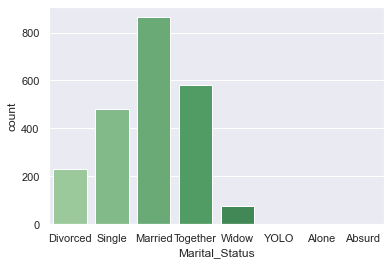

```python
 sns.countplot(x="Marital_Status", data=data, palette="Greens_d")
```

OBSERVATION:There are more married people,and the least amongst the marital status is yolo and absurd

```python
data['Income'].value_counts()
```

```
51381.5    24
7500.0     12
35860.0     4
80134.0     3
63841.0     3
           ..
46086.0     1
42243.0     1
35788.0     1
36026.0     1
94871.0     1
Name: Income, Length: 1975, dtype: int64
```

```python
income=pd.DataFrame(data[['Income']].mean(),
                      columns=['mean']).reset_index()
```

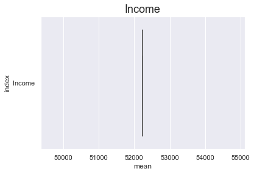

```python
sns.boxplot(x='mean', y='index',data = income, palette='Blues')
plt.xlabel('mean')
plt.title('Income', size=18);
```

OBSERVATION:The average income of the customers is about 52000

```python
data['Education'].value_counts()
```

```
Graduation    1127
PhD            486
Master         370
2n Cycle       203
Basic           54
Name: Education, dtype: int64
```

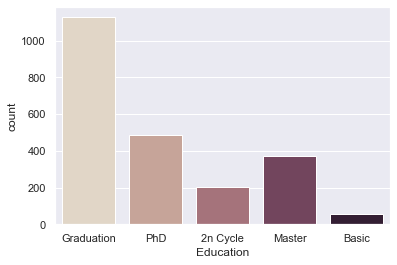

```python
sns.countplot(x="Education", data=data, palette="ch:.25")
```

OBSERVATION:We have more graduates, and very few people with basic education

```python
data['Kidhome'].value_counts()
```

```
0.0    1293
1.0     899
2.0      48
Name: Kidhome, dtype: int64
```

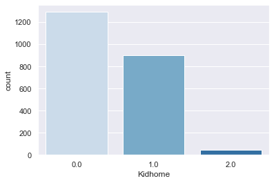

```python
sns.countplot(x="Kidhome", data=data, palette="Blues")
```

Observation: People without kids are more, while we have very few people with two kids

```python
data['Teenhome'].value_counts()
```

```
0    1158
1    1030
2      52
Name: Teenhome, dtype: int64
```

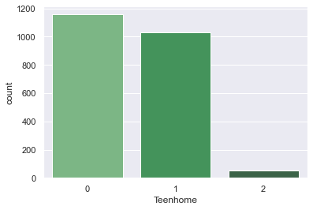

```python
sns.countplot(x="Teenhome", data=data, palette="Greens_d")
```

OBSERVATION: People without teenagers are more, while we have very few people with two teenagers

```python
data['Recency'].value_counts()
```

```
56    37
54    32
30    32
46    31
49    30
      ..
5     15
59    14
22    13
7     12
44    11
Name: Recency, Length: 100, dtype: int64
```

```python
recency=pd.DataFrame(data[['Recency']].mean(),
                      columns=['mean']).reset_index()
```

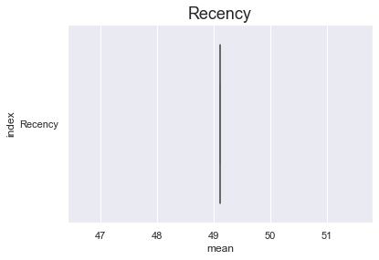

```python
sns.boxplot(x='mean', y='index',data = recency, palette='Blues')
plt.xlabel('mean')
plt.title('Recency', size=18);
```

OBSERVATION: The last time people bought products from amazone was about 49 days ago

```python
data['NumDealsPurchases'].value_counts()
```

```
1     970
2     497
3     297
4     189
5      94
6      61
0      46
7      40
8      14
9       8
15      7
11      5
10      5
12      4
13      3
Name: NumDealsPurchases, dtype: int64
```

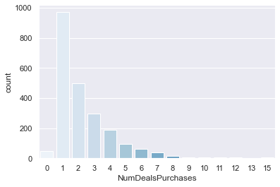

```python
sns.countplot(x="NumDealsPurchases", data=data, palette="Blues")
```

OBSERVATION: One product has the higest purchase through the discount mode of purchase

```python
data['NumWebPurchases'].value_counts()
```

```
2     373
1     354
3     336
4     280
5     220
6     205
7     155
8     102
9      75
0      49
11     44
10     43
27      2
25      1
23      1
Name: NumWebPurchases, dtype: int64
```

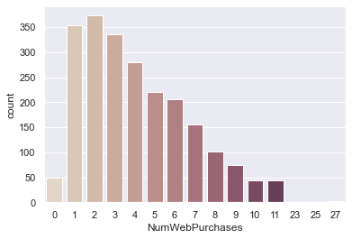

```python
sns.countplot(x="NumWebPurchases", data=data, palette="ch:.25")
```

OBSERVATION: Two products has the higest purchase through the web mode of purchase

```python
data["NumCatalogPurchases"].value_counts()
```

```
0     586
1     497
2     276
3     184
4     182
5     140
6     128
7      79
8      55
10     48
9      42
11     19
28      3
22      1
Name: NumCatalogPurchases, dtype: int64
```

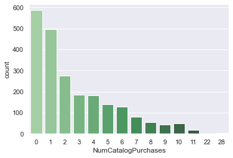

```python
sns.countplot(x="NumCatalogPurchases", data=data, palette="Greens_d")
```

OBSERVATION: The number of people who didnt buy any product from the catalog mode of purchase is high

```python
data["NumStorePurchases"].value_counts()
```

```
3     490
4     323
2     223
5     212
6     178
8     149
7     143
10    125
9     106
12    105
13     83
11     81
0      15
1       7
Name: NumStorePurchases, dtype: int64
```

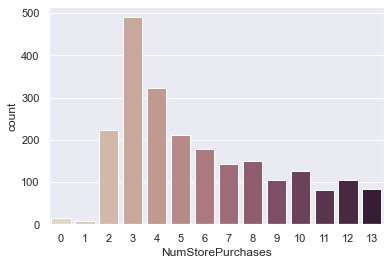

```python
sns.countplot(x="NumStorePurchases", data=data, palette="ch:.25")
```

OBSERVATION: Three products has the higest purchase through the store mode of purchase

```python
data["NumWebVisitsMonth"].value_counts()
```

```
7     393
8     342
6     340
5     281
4     218
3     205
2     202
1     153
9      83
0      11
10      3
20      3
14      2
19      2
17      1
13      1
Name: NumWebVisitsMonth, dtype: int64
```

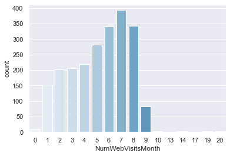

```python
sns.countplot(x="NumWebVisitsMonth", data=data, palette="Blues")
```

```python
data["Complain"].value_counts()
```

```
0    2219
1      21
Name: Complain, dtype: int64
```

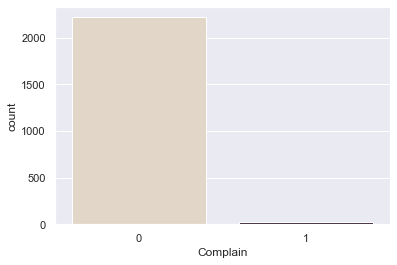

```python
sns.countplot(x="Complain", data=data, palette="ch:.25")
```

Oservation: The complaint rate is low

```python
data["Country"].value_counts()
```

```
SP     1095
SA      337
CA      268
AUS     160
IND     148
GER     120
US      109
ME        3
Name: Country, dtype: int64
```

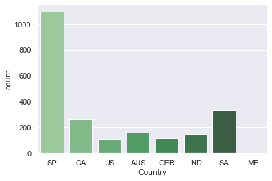

```python
sns.countplot(x="Country", data=data, palette="Greens_d")
```

OBSERVATION:Spain has the highest number of people that patronize amazon

```python
#merging the products bought
product_performance = pd.DataFrame(data[['MntWines', 'MntFruits', 'MntMeatProducts', 'MntFishProducts', 'MntSweetProducts', 'MntGoldProds']].mean(),
                      columns=['mean']).reset_index()
```

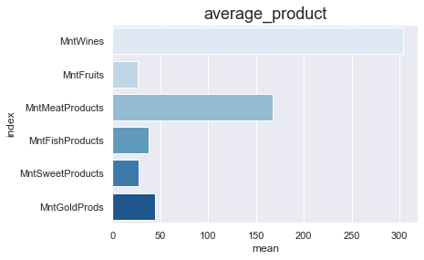

```python
sns.barplot(x='mean', y='index',data = product_performance, palette='Blues')
plt.xlabel('mean')
plt.title('average_product', size=18);
```

OBSERVATION: Wines are the most purchased product

```python
#merging the accepted campaigns
campaing_acceptance = pd.DataFrame(data[['AcceptedCmp1', 'AcceptedCmp2', 'AcceptedCmp3', 'AcceptedCmp4', 'AcceptedCmp5', 'AcceptedCmp6']].mean() * 100,
                      columns=['Percent']).reset_index()
```

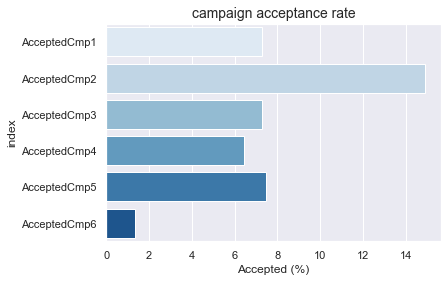

```python
sns.barplot(x='Percent', y='index', data=campaing_acceptance, palette='Blues')
plt.xlabel('Accepted (%)')
plt.title('campaign acceptance rate', size=14);
```

OBSERVATION:From the above chart, it is obvious that accepted campaign 2 was the most succesful campaign, while accepted campaign 6 was the least succesful campaign

# FACTORS AFFECTING CAMPAIGN

# RELATIONSHIP BETWEEN COUNTRY,INCOME AND ACCEPTED CAMPAIGN(2,4,6)

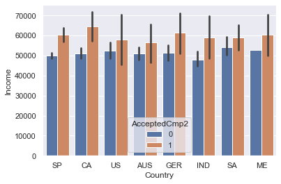

```python
sns.barplot(x="Country", y="Income",hue="AcceptedCmp2",data=data)
```

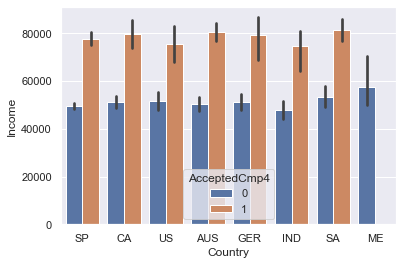

```python
sns.barplot(x="Country", y="Income",hue="AcceptedCmp4",data=data)
```

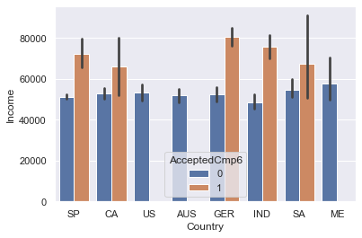

```python
sns.barplot(x="Country", y="Income",hue="AcceptedCmp6",data=data)
```

# RELATIONSHIP BETWEEN EDUCATION,INCOME AND ACCEPTED CAMPAIGN(2,4,6)

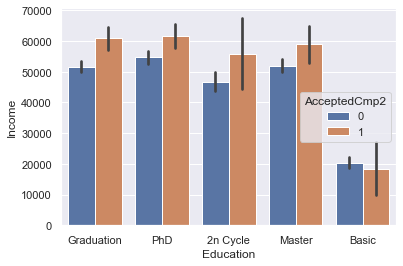

```python
sns.barplot(x="Education", y="Income",hue="AcceptedCmp2",data=data)
```

OBSERVATION:The PHD holders accepted this campaign more and they earn about 60000. While the people with basic education least accepted the campaing and they earn about 19000

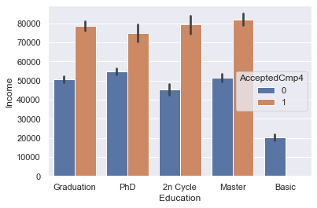

```python
sns.barplot(x="Education", y="Income",hue="AcceptedCmp4",data=data)
```

OBSERVATION:The masters holders accepted this campaign more and they earn above 80000. While the people with basic education did not accept the campaign

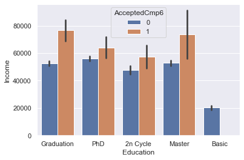

```python
sns.barplot(x="Education", y="Income",hue="AcceptedCmp6",data=data)
```

OBSERVATION:Graduates accepted this campaign more and they earn about 78000. While the people with basic education did not accept the campaign

# RELATIONSHIP BETWEEN KIDHOME,INCOME AND ACCEPTED CAMPAIGN(2,4,6)

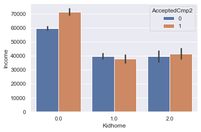

```python
sns.barplot(x="Kidhome", y="Income",hue="AcceptedCmp2",data=data)
```

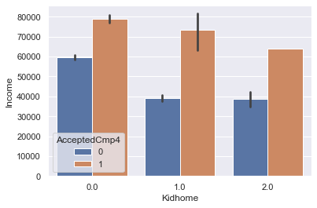

```python
sns.barplot(x="Kidhome", y="Income",hue="AcceptedCmp4",data=data)
```

OBSERVATION: People without kid at home,earning about 79000 accepted the campaign. While, people with two kids, earning 38000 least accepted the campaign

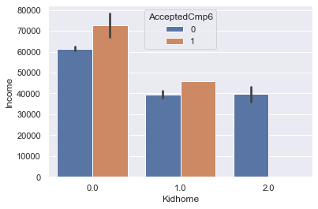

```python
sns.barplot(x="Kidhome", y="Income",hue="AcceptedCmp6",data=data)
```

OBSERVATION: People without kid at home,earning about 73000 accepted the campaign. While,people with two kids did not accept the campaign

# RELATIONSHIP BETWEEN MARITAL STATUS AND PRODUCT PURCHASED

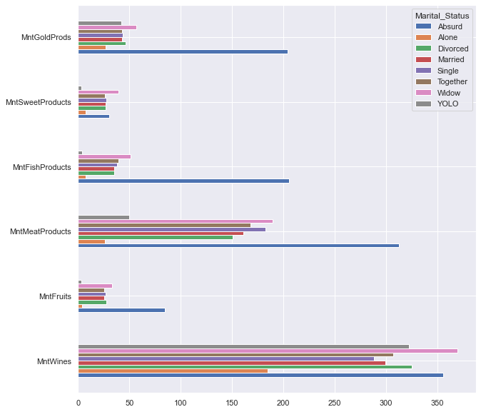

```python
data.groupby('Marital_Status')[['MntWines', 'MntFruits', 'MntMeatProducts', 'MntFishProducts', 'MntSweetProducts', 'MntGoldProds']].mean().T.plot(kind='barh', figsize=(10,10))
```

OBSERVATION: customers under absurd marital staus purchased most in goldproducts,fishproducts,meatproducts and fruitsproduct while people that fall under marital status widow bought most in sweetproduct and wineproduct

# RELATIONSHIP BETWEEN TEENHOME,MARITAL STATUS AND ACCEPTED CAMPAIGN(2,4,6)

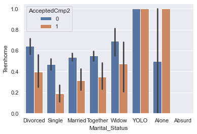

```python
sns.barplot(x="Marital_Status", y="Teenhome",hue="AcceptedCmp2",data=data)
```

OBSERVATION:People alone accepted this campaign more, while absurds did not accept the campaign

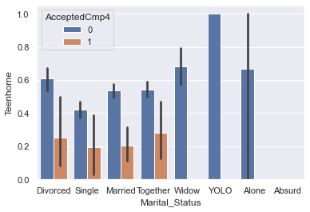

```python
sns.barplot(x="Marital_Status", y="Teenhome",hue="AcceptedCmp4",data=data)
```

OBSERVATION:People with together marital status accepted this campaign more, while widows,yolo,alone and absurd did not accept the campaign

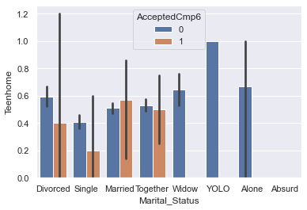

```python
sns.barplot(x="Marital_Status", y="Teenhome",hue="AcceptedCmp6",data=data)
```

OBSERVATION:Married people accepted this campaign more, while widows,yolo,alone and absurd did not accept the campaign

# RELATIONSHIP BETWEEN RECENCY,COUNTRY AND ACCEPTED CAMPAIGN(2,4,6)

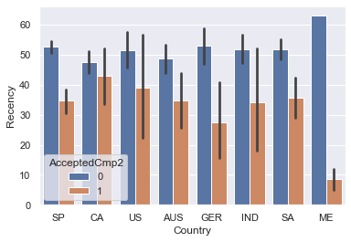

```python
sns.barplot(x="Country", y="Recency",hue="AcceptedCmp2",data=data)
```

OBSERVATION: peole living in Canada that bought products about 43 days ago accepted the campaign more, whlile peole living in Mexico that bought products about 8 days ago least accepted the campaign

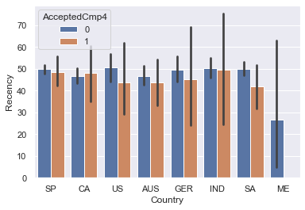

```python
sns.barplot(x="Country", y="Recency",hue="AcceptedCmp4",data=data)
```

OBSERVATION: peole living in Indian that bought products about 50 days ago accepted the campaign more. whlile, peole living in Mexico did not accept the campaign

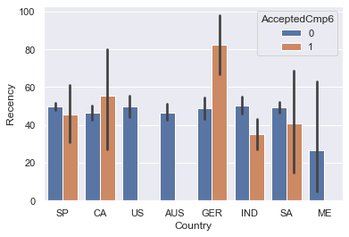

```python
sns.barplot(x="Country", y="Recency",hue="AcceptedCmp6",data=data)
```

OBSERVATION: peole living in Germany that bought products about 81 days ago accepted the campaign more. whlile, peole living in Mexico, Australia and US did not accept the campaign